# Advanced Programming

Árpád Tamási · ELTE Faculty of Social Sciences

Session 9 — 17 November 2026

## Today

**55 minutes together, 30 minutes consultation.**

How an agent works · Your video

# You, the harness, the model

## Two *core sentences*

1. AI makes its decisions using **our data**. That is what makes it useful — and that is the risk, too.
2. AI **makes decisions**: we don’t have full control over it. That is what makes it useful — and that is the risk, too.

## *Chat*

[figure not shown]

## Your data: *subscription, API, local*

[figure not shown]

*In the EU only through a cloud provider (Google Cloud, AWS), with an institutional contract. As of November 2026.

## The training *switch*

1. claude.ai → **Settings** → **Privacy**
2. **Help improve Claude**: when it is off, your chats don’t go into the training data
3. Everyone, in your own account, now — whose was on?

The switch applies to future chats. It does not take back what is already in the training data.

## Tool use: *back then*

[figure not shown]

## Tool use: *today*

[figure not shown]

## *Permissions*

[figure not shown]

## *MCP*

[figure not shown]

## *Skill*

[figure not shown]

## Inside a tool: *a harness and a model*

[figure not shown]

## *Agent*

[figure not shown]

# Your video

## The example: *Blindspot Backgammon*

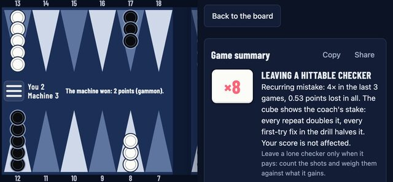

**A backgammon coach for your phone.** From your own games it names the one costly mistake you keep making, explains it in plain words, and drills your own positions until it disappears.

**For:** players who see their blunders and still don’t improve.

**Free · no account · works offline.**

Blindspot Backgammon, PRODUCT.md (Product Purpose, Users). arpadtamasi.github.io/backgammon

## Five *kinds* of video

| Kind | How it runs |
| --- | --- |
| **Launch video** | hook → promise → three features → name and address |
| **Product tour** | one complete task, through the real screens |
| **Teaser** (9:16, 20 s) | the problem → two beats → name and address |
| **Explainer** | a question → the idea, one layer at a time → the sentence to remember |
| **Future pacing** | imagine → the name → the pain goes → the outcome → the address |

**The hook speaks the viewer’s language. The promise lands by the second beat. One idea per beat. End on the name and one action.**

hyperframes.heygen.com: guides/product-launch-video, guides/faceless-explainer, prompting/examples; the product-launch-video skill, story-design.md.

## 1 · Launch video: *hook, promise, three features*

You see your mistakes.  
You still make them.

**0–4 s** Kinetic type: the second line swaps in.

Blindspot, a backgammon coach, finds the one mistake you keep making.

**4–9 s** The promise, by the second beat.

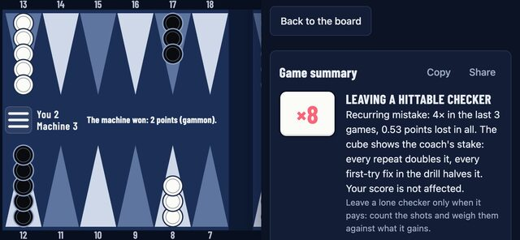

It names your blind spot.

**9–15 s** Full screen, then push in to the ×8 card.

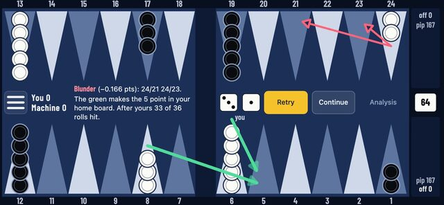

It tells you why, in words.

**15–21 s** Arrows, then the coach’s sentence.

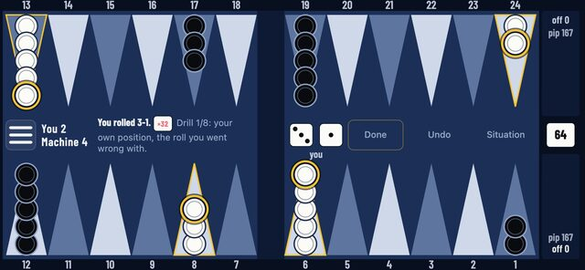

Then it drills your own positions.

**21–26 s** Drill 1/8, then the right answer.

Blindspot Backgammon · Free  
arpadtamasi.github.io/backgammon

**26–30 s** Name and address, held.

**How it runs:** hook → promise → three features → name and address.

**Why this order:** the viewer’s problem first, so they care; the promise second, so they know what it is; then three proofs, each a real screen.

**Works for:** a program with three things a user gets.

**Watch out:** each feature is something the viewer gets, not a menu item. Name the kind of program early: here, “a backgammon coach”.

HyperFrames, guides/product-launch-video: “hook stating the problem → 3 feature beats … → end card with logo + CTA”.

## 1 · Launch video: *the video*

[video not shown]

Music: “Wholesome”, Kevin MacLeod (incompetech.com), CC BY 4.0.

## 2 · Product tour: *one task, start to finish*

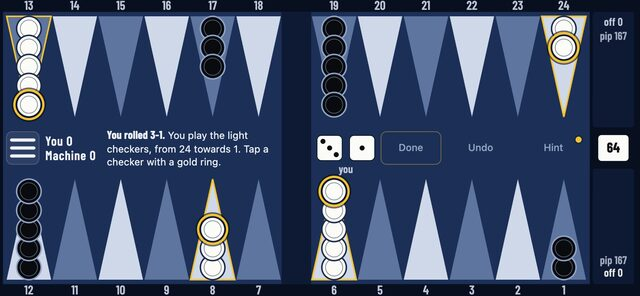

A backgammon game. You roll 3-1.

**0–4 s** The real board.

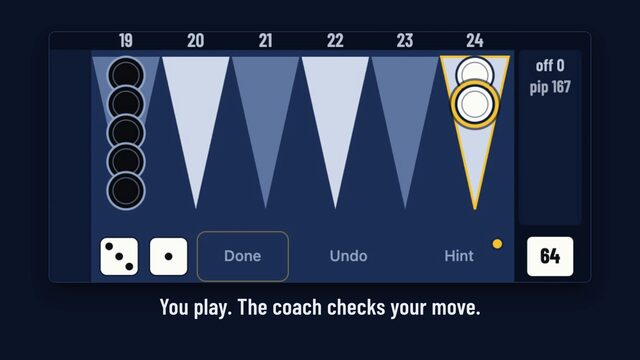

You play. The coach checks your move.

**4–8 s** Push in on your checkers and the dice.

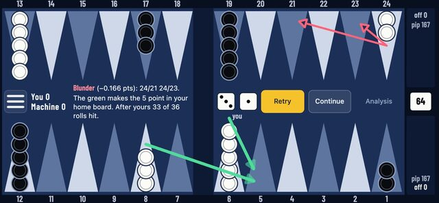

Blunder. Red is yours, green is the best.

**8–14 s** Push in to the arrows.

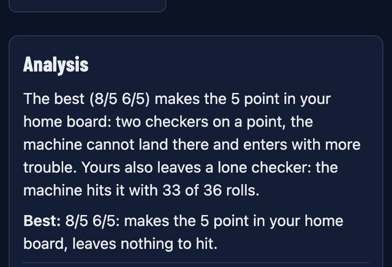

The reason: it hits you with 33 of 36 rolls.

**14–20 s** The drawer, close up.

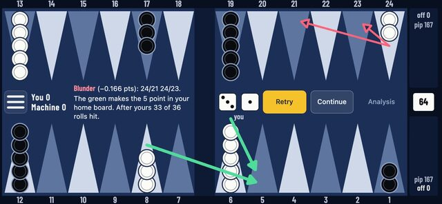

Same dice. Try again: the green makes the 5 point.

**20–26 s** Retry, then cut to the green arrows.

Blindspot Backgammon  
arpadtamasi.github.io/backgammon

**26–30 s** Name and address, held.

**How it runs:** one complete task, on the real screens, in order.

**Why it works:** the viewer sees exactly what using it is like, from the first tap to the result.

**Works for:** a program with one core task that is quick to show.

**Watch out:** one task only; a second one makes it a feature list. Use screens from one run, so the board does not change between beats.

HyperFrames, guides/product-launch-video: “Product tour: one complete task through the real screens”.

## 2 · Product tour: *the video*

[video not shown]

Music: “Wholesome”, Kevin MacLeod (incompetech.com), CC BY 4.0.

## 3 · Teaser, 9:16: *the problem, two beats, the name*

Same backgammon mistake.  
Every game.

**0–4 s** Big type, hard cuts.

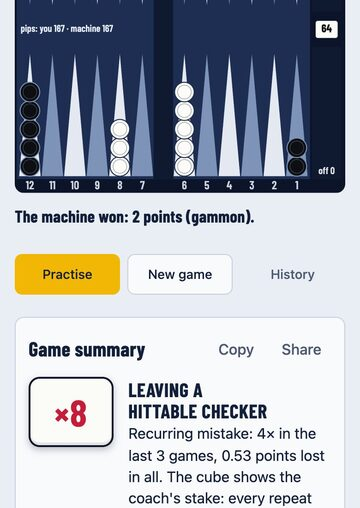

Now it has a name.

**4–10 s** Push in to ×8.

[figure not shown]

Fix it here.

**10–16 s** The drill.

Blindspot Backgammon. Find yours.  
arpadtamasi.github.io/backgammon

**16–20 s** Name and address, held.

**How it runs:** 20 seconds, portrait, for a feed.

**Why it works:** one problem, two beats, the name. Nothing to read while scrolling.

**Works for:** a short post where people scroll past.

**Watch out:** three words per caption. Keep text in the middle of the frame: on TikTok and Reels the app’s buttons cover the bottom.

HyperFrames, prompting/examples: teaser “0–4s problem in one line, big type; 4–16s two feature beats … three-word caption; 16–20s logo + … end card”.

## 3 · Teaser: *the video*

[video not shown]

Music: “Wholesome”, Kevin MacLeod (incompetech.com), CC BY 4.0.

## 4 · Explainer: *one idea, one layer at a time*

Why don’t you get better at backgammon, even when you see your blunders?

**0–4 s** A question.

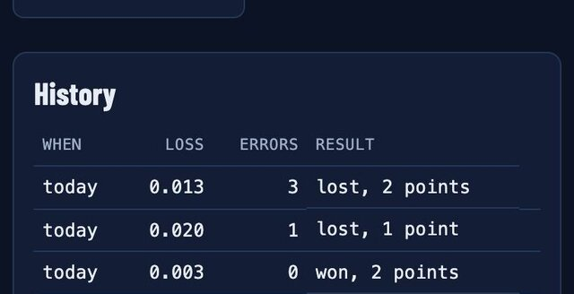

A blunder list shows every mistake once.

**4–10 s** Rows appear one by one.

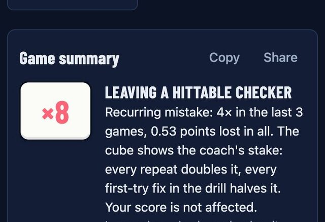

Your blind spot is the one that comes back.

**10–17 s** 4× in the last 3 games.

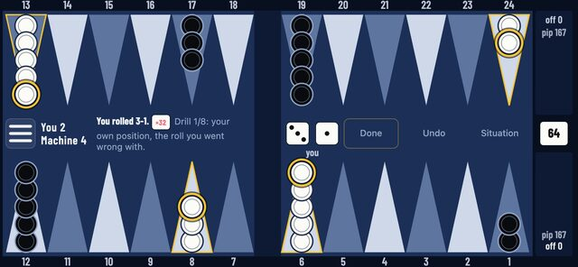

Learn why, then drill your own positions.

**17–24 s**

Fix the one that comes back.  
arpadtamasi.github.io/backgammon

**24–30 s** The sentence to remember.

**How it runs:** a question → the mechanism, layer by layer → the sentence to remember.

**Why it works:** if they understand the idea, they want the tool.

**Works for:** programs whose value is an idea: a method, a measurement, a way of looking.

**Watch out:** the main idea is clear by the second scene. Keep the opening question short: ours had 13 words for 4 seconds, too many.

HyperFrames, guides/faceless-explainer: “Understand one idea (open with a question, reveal the mechanism one layer at a time)”; “One idea per scene”.

## 4 · Explainer: *the video*

[video not shown]

Music: “Wholesome”, Kevin MacLeod (incompetech.com), CC BY 4.0.

## 5 · Future pacing: *imagine, then the name*

Imagine a backgammon coach who has watched all your games.

**0–5 s** Imagine.

Blindspot Backgammon

**5–9 s** The name.

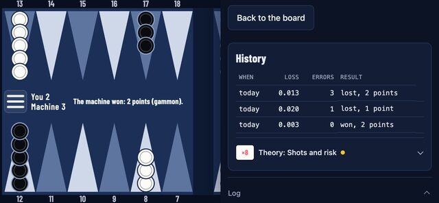

It remembers them: your last 20 games.

**9–15 s** Real today.

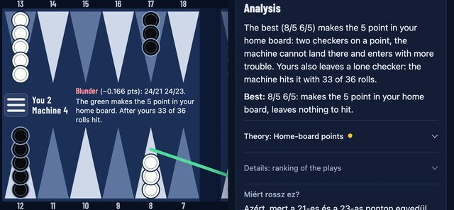

One day: ask it anything about your game.

**15–22 s** Illustration, marked.

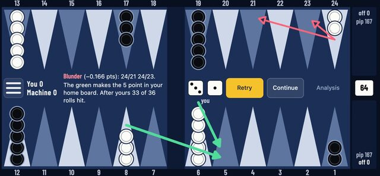

And the mistake stops coming back.

**22–26 s** The outcome.

Blindspot Backgammon  
arpadtamasi.github.io/backgammon

**26–30 s** Name and address, held.

**How it runs:** imagine → the name → the pain goes → the outcome → the address.

**Why it works:** it shows where the program is going, not only where it is.

**Works for:** projects with a clear next step; your demo day ends with “what’s next” anyway.

**Watch out:** start and end on what works today; the vision frame says “Illustration”.

product-launch-video skill, story-design.md: “Future Pacing: imagine → name product → remove pain → mechanism → outcome → CTA”.

## 5 · Future pacing: *the video*

[video not shown]

Music: “Wholesome”, Kevin MacLeod (incompetech.com), CC BY 4.0.

## HyperFrames: *a video is a web page*

```html
<div data-composition-id="main" data-width="1080" data-height="1920"
     data-start="0" data-duration="20">
  <div class="clip" data-composition-src="compositions/hook.html"
       data-start="0" data-duration="4"></div>
  <div class="clip" data-composition-src="compositions/named.html"
       data-start="4" data-duration="6"></div>
  …
</div>
```

- **When:** `data-start` and `data-duration` on every scene and element.
- **Rendering:** headless Chrome steps to each frame and takes a picture; FFmpeg joins them into an MP4. **The same input gives the same video.**
- **Formats:** 16:9 for a page, 1:1 for a feed, 9:16 for Shorts and Reels.

github.com/heygen-com/hyperframes, README: “How It Works”; hyperframes.heygen.com, guides/product-launch-video. The snippet is from our teaser’s index.html, shortened.

## What it builds from: *skills, blocks, templates*

| **Skills** for your agent | `/hyperframes`, `/hyperframes-cli`, `/hyperframes-registry`, `/media-use` … |
| --- | --- |
| **Blocks**, about 450 | captions, transitions, kinetic type, charts, maps |
| **Templates** | play-mode, product-promo, kinetic-type, decision-tree, swiss-grid, warm-grain, nyt-graph, vignelli |
| **frame.md** | your page’s design system, rewritten for video |
| **Commands** | `init` · `preview` · `check` · `render` |

It needs **Node 22+ and FFmpeg**. Your agent runs the commands; you look at the frames.

hyperframes.heygen.com: catalog, examples; github.com/heygen-com/hyperframes, README.

## By Saturday, 21 November, 20:00

**Homework 10: your promo video, on your promo page.**

- About **30 seconds**, for someone who has never heard of your program
- It **adds something** your page can’t say; it doesn’t repeat it
- **Real screens.** Anything not built yet is marked as such
- It works **without sound**
- On your **promo page**, the step in your **PROCESS.md**, pushed
- You submit **the address of your page**

If HyperFrames won’t run: **Video help** on Canvas. If nothing helps, record your screen and add captions.

Late until Monday 23 November, 20:00, for half.

**Next week: your presentation.** Slides by Saturday 28 November. Demo days: 1 and 8 December.